# Part B. Reshaping data.

The file `rhpi.csv` contains data from the International House Price Database from the Federal Reserve Bank of Dallas. It records the real housing price index. The raw data is available [here](https://www.dallasfed.org/institute/houseprice/~/media/documents/institute/houseprice/hp1701.xlsx):

Open the `.csv` file into `R`.

```r
rhpi <- read.csv("rhpi.csv", stringsAsFactors = FALSE)
```

1. Use `head` to explore the first few rows of the dataset. Is it in long or wide format? Is it a `tidy` dataset? Why or why not? (10 points)

```r
head(rhpi)
```

```
##             X X1975.Q1 X1975.Q2 X1975.Q3 X1975.Q4 X1976.Q1 X1976.Q2
## 1   Australia    39.16    38.50    38.61    37.76    37.95    38.12
## 2     Belgium    44.51    45.66    47.01    48.67    50.60    52.26
## 3      Canada    59.42    59.20    59.89    59.54    59.20    59.85
## 4 Switzerland    93.83    91.83    90.41    88.91    86.83    85.89
## 5     Germany   108.59   108.46   109.07   109.30   109.90   110.60
## 6     Denmark    57.37    57.61    59.07    58.07    58.44    57.28
##   X1976.Q3 X1976.Q4 X1977.Q1 X1977.Q2 X1977.Q3 X1977.Q4 X1978.Q1 X1978.Q2
## 1    38.36    37.90    37.94    37.73    37.75    37.42    37.75    37.44
## 2    53.74    55.20    56.32    57.98    59.73    61.40    62.63    63.81
## 3    58.89    57.63    55.91    55.30    54.59    56.12    55.83    56.05
## 4    84.98    85.19    84.54    85.10    85.71    85.65    87.21    88.01
## 5   111.24   112.64   113.76   115.29   116.85   118.75   121.49   122.94
## 6    57.34    58.64    57.49    59.28    60.47    62.72    63.83    64.63
##   X1978.Q3 X1978.Q4 X1979.Q1 X1979.Q2 X1979.Q3 X1979.Q4 X1980.Q1 X1980.Q2
```

[output cut: 139 more lines]

**It is in wide format. It is not a tidy dataset because multiple columns correspond to the same variable.**

2. You may find out that the first column name is empty. You can update the first column name to `country` by using the `colnames` function (5 points)

```r
colnames(rhpi)[1] <- "country"
```

3. Reshape the dataset so that it becomes *tidy*. Note that in most cases this means reshaping from wide to long. You can use the `melt` function from the `reshape` package or other functions. (15 points).

```r
library(reshape2)
rhpi.long <- melt(rhpi, id.vars="country", value.name="index")
head(rhpi.long)
```

```
##       country variable  index
## 1   Australia X1975.Q1  39.16
## 2     Belgium X1975.Q1  44.51
## 3      Canada X1975.Q1  59.42
## 4 Switzerland X1975.Q1  93.83
## 5     Germany X1975.Q1 108.59
## 6     Denmark X1975.Q1  57.37
```

4. Filter the data frame so that it only contains the data that corresponds to the US. Then, produce a line plot that tracks the housing price over time. What do you find? (10 points)

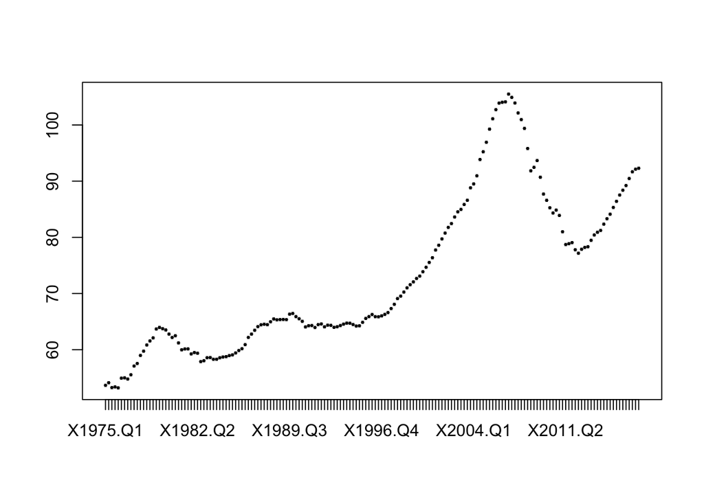

```r
us <- rhpi.long[rhpi.long$country=="US",]
plot(us$variable, us$index, type="l")
```

```r
library(lubridate)
```

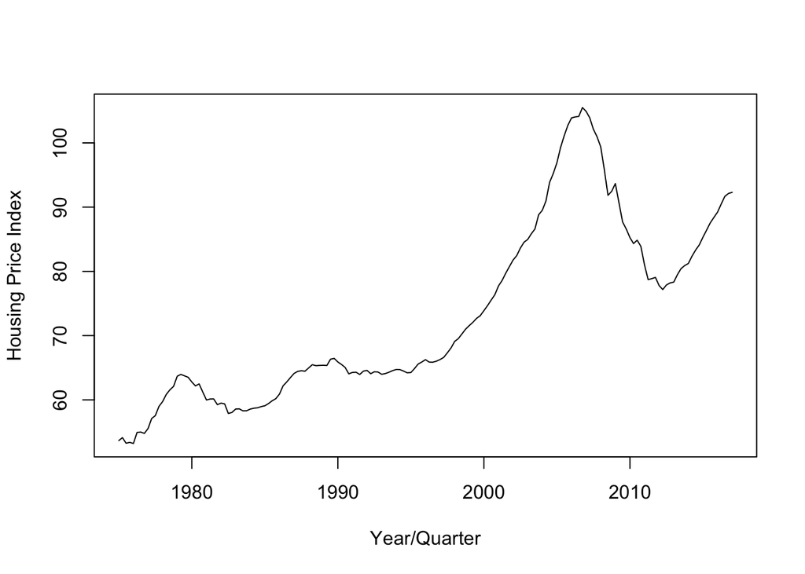

```r
us$variable <- gsub('X|Q', '', as.character(us$variable))
us$q <- parse_date_time(us$variable, orders = "Yq")
plot(us$q, us$index, type="l", xlab="Year/Quarter", ylab="Housing Price Index")
```

*We can clearly see the housing bubble and then the financial crisis after 2008.*

5. Write a function that takes a country name as input and returns the average housing price in the last 5 years. Then, show that it works by running it for 3 different countries. (10 points)

```r
rhpi.long$year <- substr(as.character(rhpi.long$variable), 2, 5)

avg_hp <- function(country){
  df <- rhpi.long[rhpi.long$country==country & rhpi.long$year > 2012,]
  return(mean(df$index))
}

avg_hp("Australia")
```

```
## [1] 135.2071
```

```r
avg_hp("Belgium")
```

```
## [1] 121.0641
```

```r
avg_hp("Canada")
```

```
## [1] 154.4176
```